# Analyzing and Forecasting the Fluctuations in Stack Overflow Website Traffic

Perry Deng

12/4/2020

# Introduction

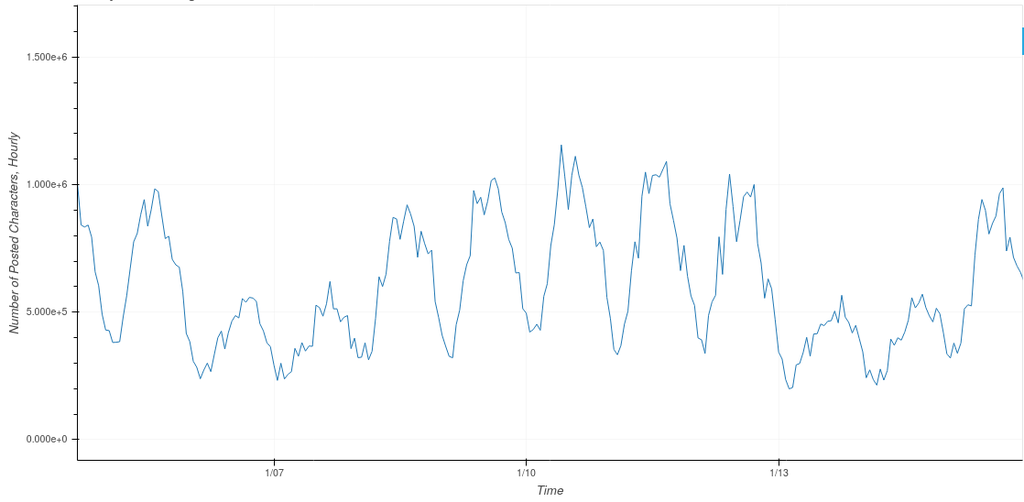

Visualization of Stack Overflow Hourly Traffic around 2018.01.10; Interact the visualization on [my webapp](http://pdeng.student.rit.edu)

Stack Overflow is a popular Q&A site used by programmers to share and access knowledge, with over 14 million registered users, 21 million questions, and 31 million answers as of 2020 December [3]. We found wild periodic fluctuations in Stack Overflow traffic; for example, there is almost twice as much traffic around noon on a weekday than there is at night. This means that, if the website infrastructure is optimized to handle “peak load” performance, half of the infrastructure will not be utilized at night. To see the potential magnitude of this resource waste, we can look at another large website, Netflix, which is estimated to spend 25 millions USD per month on tech infrastructure [5]. If a website captures the fluctuations quantitatively, and forecasts the traffic in advance, it can reduce the scale of its IT infrastructure [4]. To understand why this is the case, we can borrow some terminologies from the utility industry.

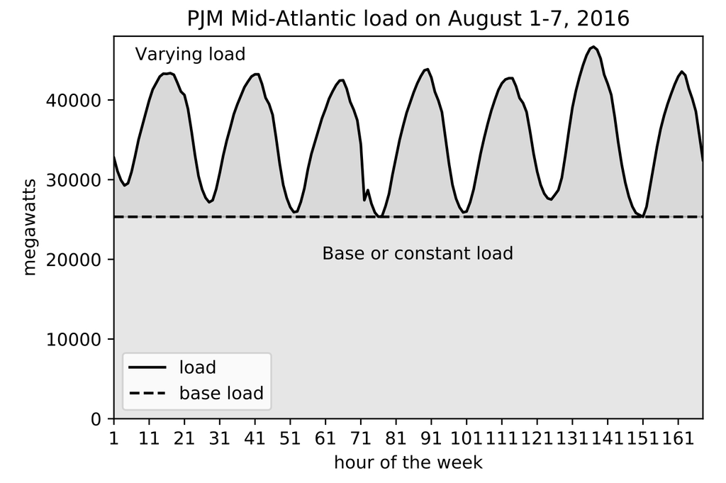

Analogy: Fluctuations in Hourly Eletricity Demand; Credit: [Knowledge@Wharton](https://knowledge.wharton.upenn.edu/article/is-a-more-rapid-transition-to-renewable-energy-on-the-verge-of-being-unstoppable/)

We observe in above figure that the fluctuations in the rate of electricity demand, or website traffic, can be divided into “base load” and “varying load”. The proportion of infrastructure used to handle base load is utilized 100% of the time in a given time frame, whereas the proportion of infrastructure used to handle varying load is utilized less or very little time depending on the capacity of the infrastructure. In the context of web hosting, static, on-premise infrastructure is suitable for base load because its capacity is fully utlized 100% of the time. As for varying load, many strategies are available for cost optimization. One simple strategy is to reserve cloud infrastructure in advance (which is cheaper than on-demand cloud infrastructure), based on the predicted fluctuations. However these planning strategies require reliable predictions in advance.

In this report we provide an analysis on the Stack Overflow traffic over time, and compare several approaches for predicting traffic months or years ahead. These approaches are based on conventional time series models, such as Autoregressive Integrated Moving Average (ARIMA) processes and Fourier analysis. We provide a simple method for stationarizing the time series, so that our models can be applied to websites with varying growth in usage over time. We find that seasonal ARIMA models have disappointing forecasting accuracies (about 40% off relatively), likely due to inability to account for multiple periodic patterns simultaneously. Our ad-hoc Fourier extrapolation model has surprisingly strong forecasting accuracy (about 10% off relatively), but its statistical properties are not well understood.

For readers’ convenience, we include the source code (a mix of R and Python) for reproducing the analysis, which can be optionally viewed by clicking on the “Code” button. This report is intended for audience with rudimentary knowledge in applied data analysis, and is light on the mathematical, statistical, and algorithmic details.

```r
# R
# html output options with RMarkdown
knitr::opts_chunk$set(echo = TRUE, message=FALSE, fig.align='center', results='hide', fig.width=6, fig.height=4)
# python3/R interoperability
library(reticulate)
use_python("/usr/bin/python3")
matplotlib <- import("matplotlib")
matplotlib$use("Agg", force = TRUE)
```

# Data Collection

Stack Overflow regularly upload their data in XML format for public access [2], which are now over 100 gigabytes. In summer 2019 we processed their data into structured form and stored them into a cloud database. We utilized parallel map reduce algorithms in PySpark to extract statistics from the data, particularly the number of characters posted each hour, which serves as a good proxy variable for website traffic over time - since actual website traffic in terms of visitors per minute or requests per second is likely going to be a constant multiple of this proxy variable, any conclusion we make about the periodic fluctuations in the proxy variable will hold true for website traffic. We stored the calculations in the database so that we can easily access it for data analysis. The data processing and map reduce implementations are not discussed in details in this document, and the corresponding source code is also omitted. However, it can be found in our github repository [1]. The remainder of this document focuses on data analysis.

# Data Analysis

After data extraction and transformation, we have close to 100 thousand datapoints from August 2008 to June 2019, in the format seen below. “size” refers to the number of characters posted each hour, which is our proxy variable for hourly web traffic.

```python
# Python
from matplotlib import pyplot as plt
import pandas as pd
import numpy as np

import mysql.connector
import pandas.io.sql as psql

def query(statement):
  """
  establishes a connection and makes a query
  :param statement: sql
  :return: pandas data frame
  """
  conn = mysql.connector.connect(user=USERNAME, password=PASSWORD,
                                 host='127.0.0.1', database=SCHEMA)
  df = psql.read_sql_query(statement, conn)
  conn.close()
  return df

# query database
df = query("SELECT size, time FROM hourly_post_sizes WHERE siteId=" + str(156) + " ORDER BY time ASC")
# convert to time series format
df['time'] = pd.to_datetime(df["time"])
df.set_index('time', inplace=True)

# fix duplicates by removing the first occurances
df = df[~df.index.duplicated(keep='first')]

# fill in missing hour increments for when nothing is posted by users
df = df.asfreq('H').fillna(0)
```

```r
# R
df = py$df
library(kableExtra)
kable_styling(kable(tail(df, n=5), format = "html", table.attr = "style='width:30%;'", booktabs = T), position="center")
```

|  | size |
| --- | --- |
| 2019-06-01 16:00:00 | 599877 |
| 2019-06-01 17:00:00 | 502281 |
| 2019-06-01 18:00:00 | 620185 |
| 2019-06-01 19:00:00 | 478912 |
| 2019-06-01 20:00:00 | 417681 |

### Trend and Stationarization

Before we proceed with further analysis, let’s visualize the series below.

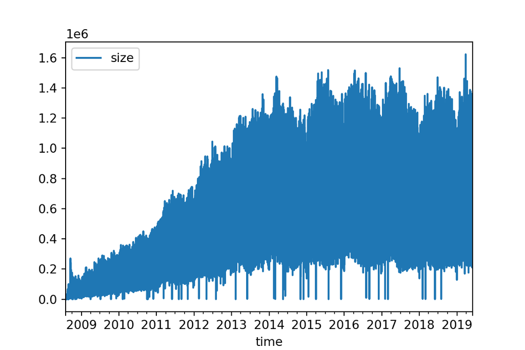

```python
# Python
df.plot()
```

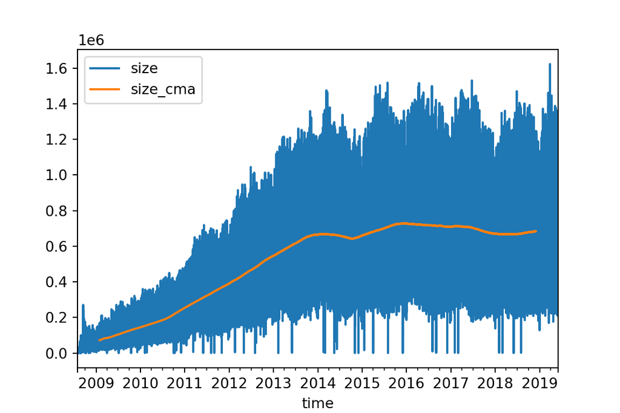

```python
# Python
# integrate out oscillations with centered moving averages
df = df.join(df.rolling(int(24*365.25), center=True).mean(), rsuffix="_cma")
df.plot()
```

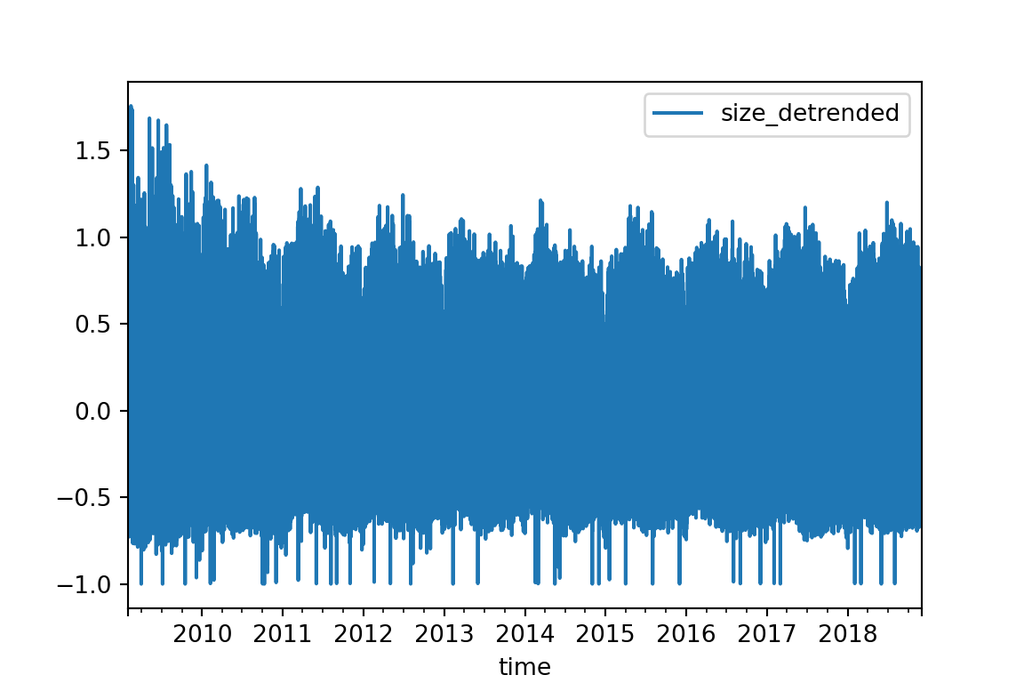

```python
# Python
filtered_df = df[df['size_cma'].notnull()].copy()
filtered_df['size_detrended'] = filtered_df['size'].values/filtered_df['size_cma'].values - 1
filtered_df[['size_detrended']].plot()
```

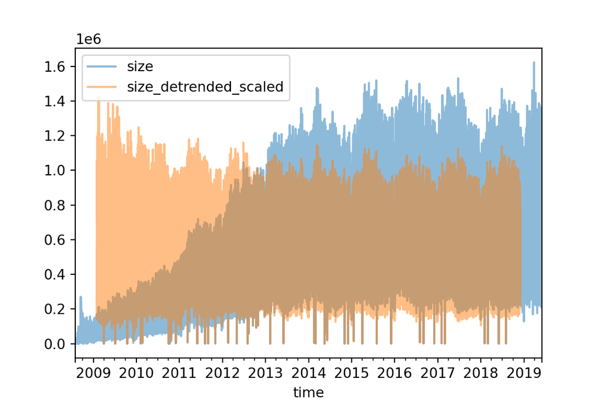

```python
# Python
filtered_df['size_detrended_scaled'] = (filtered_df['size_detrended'] + 1) * filtered_df['size_cma'].mean()
df.join(filtered_df[['size_detrended_scaled']])[['size', 'size_detrended_scaled']].plot(alpha=0.5)
```

The stationarity exhibited above is crucial for many mathematical and statistical models, and by using a stationary transformation we can ensure that our conclusions are applicable to other websites which may or may not exhibit long term trends in their traffic. Since in our case the trend flattens out in the later years, for forecasting purpose we can simply use the last available moving average and multiply it by our predicted $y_{periodic, t} + 1$ to obtain an estimate for the inversely transformed, original series, although in other cases a separate model to forecast the trend might be necessary.

### Spectral Analysis

We visually analyze the periodicity in the original series by taking progressively closer looks at our transformed series $y_{transformed, t}$. First we look at the timeframe 2011-2013

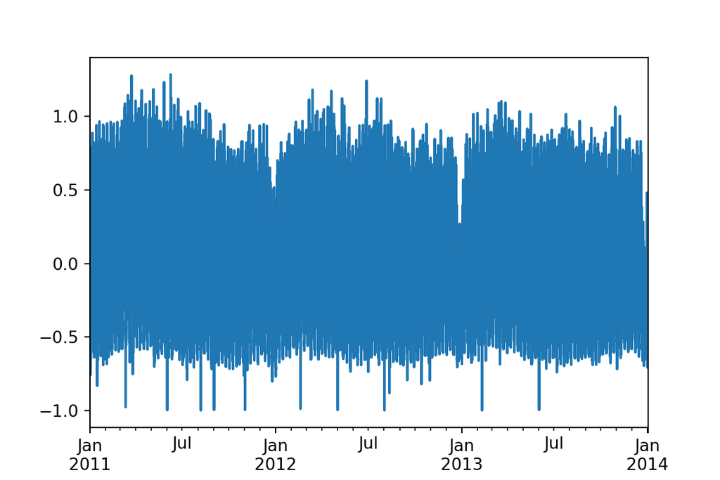

```python
# Python
filtered_df['2011-01-01':'2014-01-01']['size_detrended'].plot()
```

We can see that in the scale of months, there is less traffic around December and January, but the difference is not huge compared to the swings that are more frequent. Let’s focus on the July of 2011.

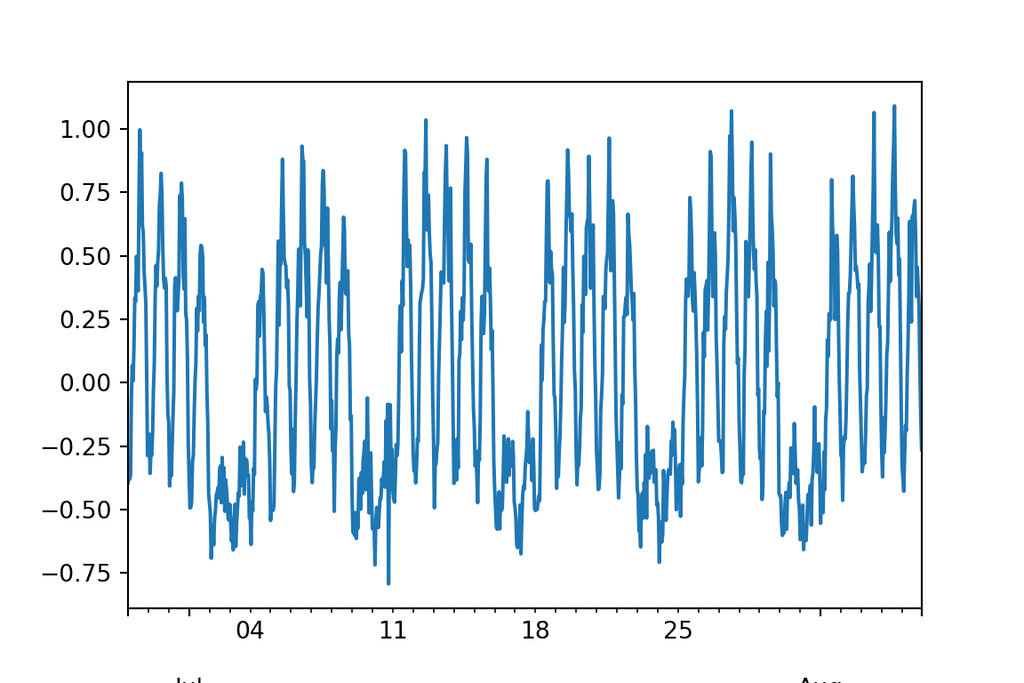

```python
# Python
filtered_df['2011-06-28':'2011-08-05']['size_detrended'].plot()
```

Clearly, there is more traffic on weekdays than on weekends. We can take another step closer to look at just July 14th and 15th of 2011.

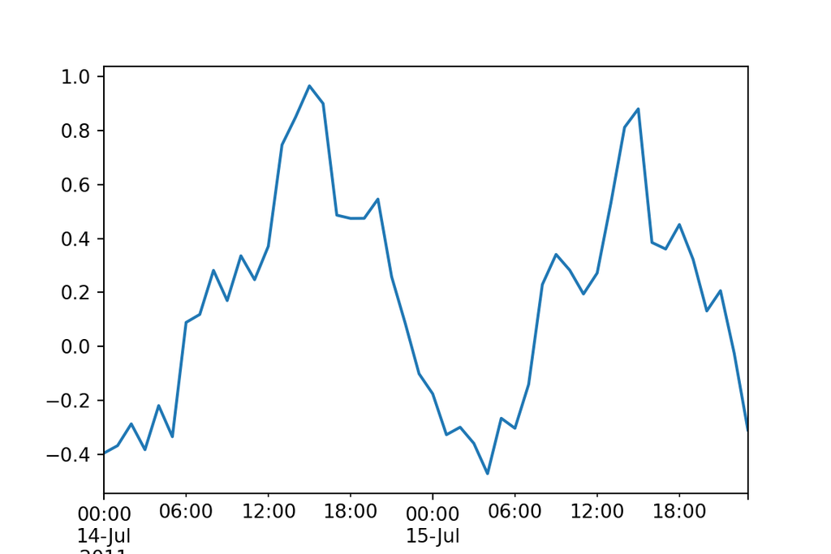

```python
# Python
filtered_df['2011-07-14':'2011-07-15']['size_detrended'].plot()
```

It’s also obvious that there is more traffic in daytime than at night time.

These patterns suggest that yearly, weekly, and daily periodic fluctuations make up the periodic component of our time series. To confirm that we are not missing any patterns, we run the Discrete Fourier Transform (DFT) on our series. DFT fits waves onto datapoints, and is excellent for finding periodic patterns because recurring fluctuations can be thought of as waves. In the following periodogram we plot the amplitudes of waves at different frequencies. We leave out the extremely high frequency waves (peaking more than once every five hour); extremely low frequency waves (peaking less than once every year); and extremely low amplitude waves (peaking less than 0.01), because they can be thought of as noise and trend components.

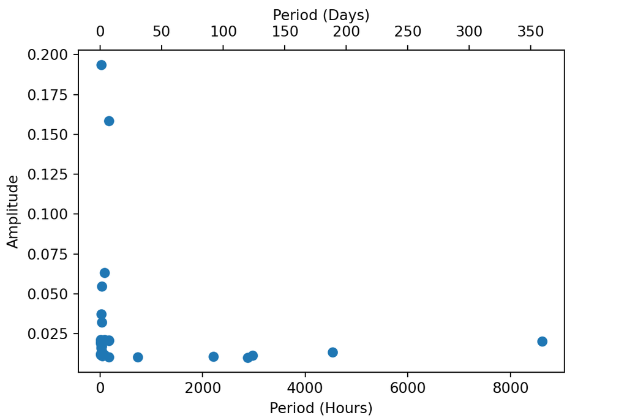

```python
# Python
sample_rate = 60**-2 # once per hour in Hz
n = len(filtered_df)
signal_fft = np.fft.fft(filtered_df['size_detrended'])
non_constant_signal_fft = signal_fft[1:] # we ignore first term has frequency of zero which is just a constant term
amplitudes = np.absolute(non_constant_signal_fft)/n

frequencies_hz = (np.arange(0, n, 1) * sample_rate / n)[1:]
periods_hours = (1/frequencies_hz)/((60**2))
periods_days = (1/frequencies_hz)/((60**2)*24)
filtered_indices = (periods_hours < 5) + (periods_days > 380.25) + (amplitudes < 0.01)

fig, ax = plt.subplots()
ax.set_xlabel("Period (Hours)")
ax.set_ylabel("Amplitude")
secax = ax.secondary_xaxis('top', functions=(lambda x:x/24, lambda x:x*24))
secax.set_xlabel('Period (Days)')
ax.scatter(periods_hours[~filtered_indices], amplitudes[~filtered_indices])
```

We see that there is indeed a relatively weak wave signal with a frequency of once per year, which likely correspond to the December and January traffic slump. In addition, there are even weaker waves with a frequency of around half a year (180 days), thrice a year (120 days), every quarter (90 days), as well as monthly (30 days). However the signal at those frequencies are so weak that it is not clear whether they correspond to meaningful periodic patterns. We see that the stronger waves are those with a faster frequency of < 15 days, at which we will take a closer look.

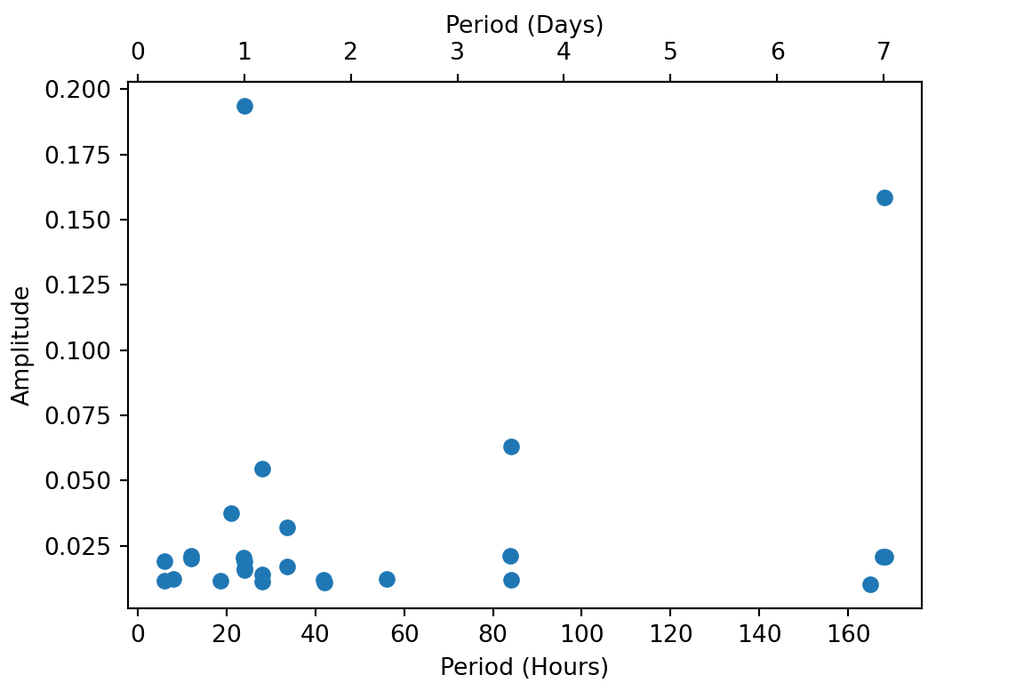

```python
# Python
filtered_indices = (periods_hours < 5) + (periods_days > 15) + (amplitudes < 0.01)

fig, ax = plt.subplots()
ax.set_xlabel("Period (Hours)")
ax.set_ylabel("Amplitude")
secax = ax.secondary_xaxis('top', functions=(lambda x:x/24, lambda x:x*24))
secax.set_xlabel('Period (Days)')
ax.scatter(periods_hours[~filtered_indices], amplitudes[~filtered_indices])
```

It’s worth noting the x axis is only 7 days long rather than the expected 15 days in the above figure. This is because all waves with frequencies in between have amplitudes smaller than 0.01, thus filtered out as noise. Aside from that, the waves here are dominated by frequencies of around once per week and once per day. Unexpectedly, there is also a relatively strong signal that takes place approximately twice a week (every 3.5 days). This might result from peculiar behaviors of DFT as it tries to fit the datapoints exactly, but might also from legitimate periodic patterns.

In a nutshell, the results from Fourier analysis in the frequency domain mostly agree with our prior visual analysis on the transformed time series. However the Fourier terms also suggest the possible existence of weaker periodic patterns that do not take place annually, weekly, or daily. These weaker patterns occur biannually, triannually, quarterly, monthly, or biweekly. Those may simply be noise, or correspond to common deliverable deadlines for programmers.

# Forecasting

This section examines several approaches for predicting hourly traffic months in advance. We first outline our methodology. Then we iteratively develop and compare several predictive models.

### Methodology

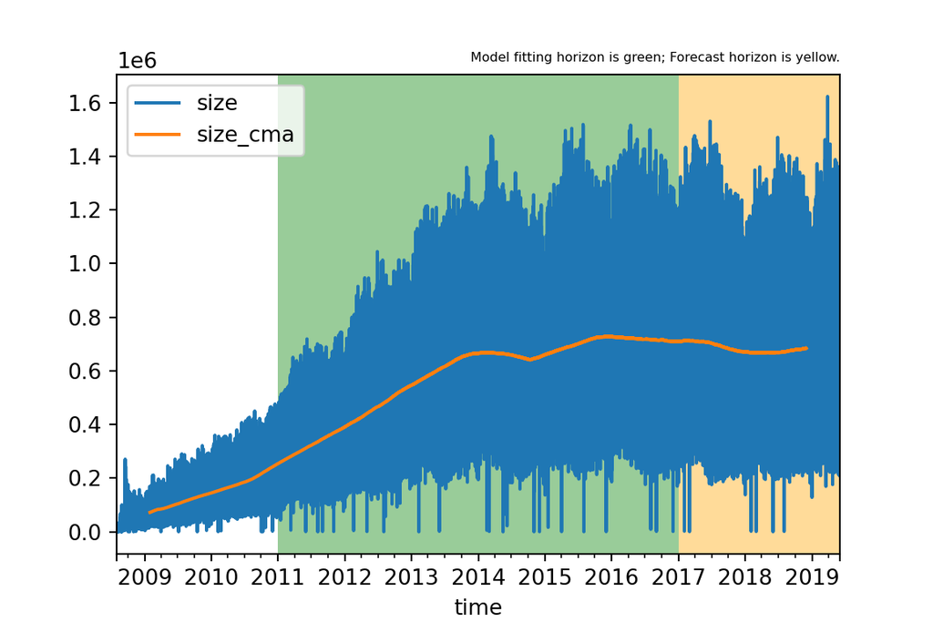

```python
# Python
fit_horizon_start = np.datetime64("2011-01-01T00:00:00")
forecast_horizon_start = np.datetime64("2017-01-01T00:00:00")
df['t'] = df.index - fit_horizon_start
fitting_horizon = filtered_df[fit_horizon_start:forecast_horizon_start - np.timedelta64(1,"h")].copy()
forecasting_horizon = df[forecast_horizon_start:].copy()
num_forecasts = len(forecasting_horizon)
forecast_indices = df.index >= forecast_horizon_start
cmas = df['size_cma'].values.copy()
cmas[forecast_indices] = fitting_horizon['size_cma'].values[-1]
df['cma_for_extrapolation'] = cmas

def plot_datetime_df_with_highlighted_horizon(dataframe):
    ax = dataframe.plot()
    ax.axvspan(fit_horizon_start, forecast_horizon_start, facecolor='green', edgecolor='none', alpha=.4)
    ax.axvspan(forecast_horizon_start, dataframe.index[-1], facecolor='orange', edgecolor='none', alpha=.4)
    ax.set_title('Model fitting horizon is green; Forecast horizon is yellow.', loc='right', fontdict={'fontsize':6})
    return ax

plot_datetime_df_with_highlighted_horizon(df[['size', 'size_cma']])
```

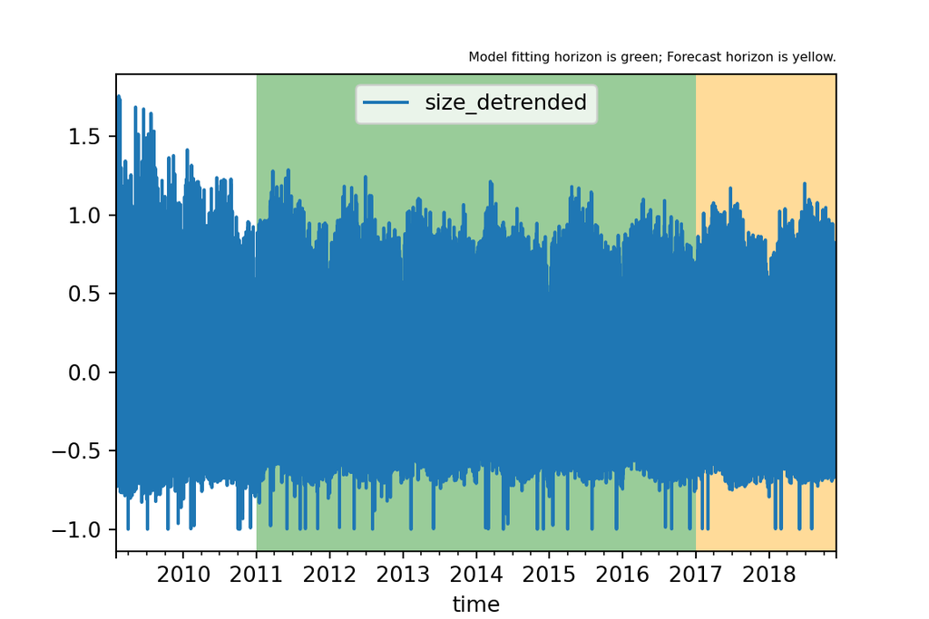

```python
# Python
plot_datetime_df_with_highlighted_horizon(filtered_df[['size_detrended']])
```

We use the following criteria for comparing the models:

1. Normalized Root Mean Square Error (NRMSE). This is calculated by taking the RMSE of forecasts, and then divide the RMSE by the mean values of observations to rescale the value for interpretability. We use this instead of mean absolute percentage error (MAPE) because no questions were asked in Stack Overflow during certain hours in the dataset ($y_t = 0$). This leads to division by zero when calculating MAPE. In short, NRMSE measures the raw predictive power of our model. The closer NRMSE is to 0, the better the models are according to this criterion.
2. Prediction Interval Capture Rate (PICR). This calculates the intervals of likely values (typically based on normal distributions) on new predictions with 80% confidence level, using information available in the fitting horizon. It then measures the proportion of confidence intervals that successfully capture actual values. In short, PICR is a simple way to measure the statistical inferential power of our model, which can be useful in more advanced applications such as anomaly detection and risk analysis. The closer PICR is to 0.8, the better the models are according to this criterion.

While more advanced metrics exist, we use the two above due to their simplicity.

### SARIMA

For our Seasonal Autoregressive Integrated Moving Average (SARIMA) models, we use existing implementations in R for fitting parameters, forecasting new values, and building prediction intervals on $y_{transformed}$. SARIMA is a stochastic process widely used to model time series data. It is based on the ARIMA process, with a seasonal component to account for periodic patterns. To fit the best SARIMA models for our task, we first look at the PACF and ACF charts to narrow down the likely values for AR and MA parameters. Then, an R library method yields us the best model based on Akaike Information Criterion (AIC) using our range of likely parameter values, through a combinatorial search heuristic [6], for a predetermined seasonal lag. We use this procedure for seasonal lags of 1 day, 1 week, and 1 year. In the end, we compare the best SARIMA models for each respective seasonal lag using NRMSE and PICR. Note that the parameter for I in SARIMA is not relevant to our task since our series has already been made stationary.

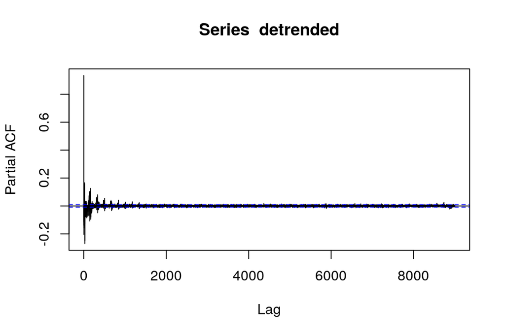

```r
# R
fit_df = py$fitting_horizon
detrended = fit_df['size_detrended']
pacf(detrended, lag.max=9000)
```

The Partial Autocorrelation Function (PACF) figure shows the correlation between data points that are $k$ lags apart (in our case, one lag is one hour) when factoring out the linear relationships of $k-1$ order. This allows us to estimate whether there is an autoregressive (AR) relationship of $k$th order, which helps determine the parameter for AR. When plotted on an x axis of 9000 lags (about 1 year), we see that partial autocorrelations are weak between data points more than 1000 hours apart. In the figure below we take a closer look at the first 800 lags (about 1 month), first 200 lags (about 1 week), and first 50 lags (about 2 days).

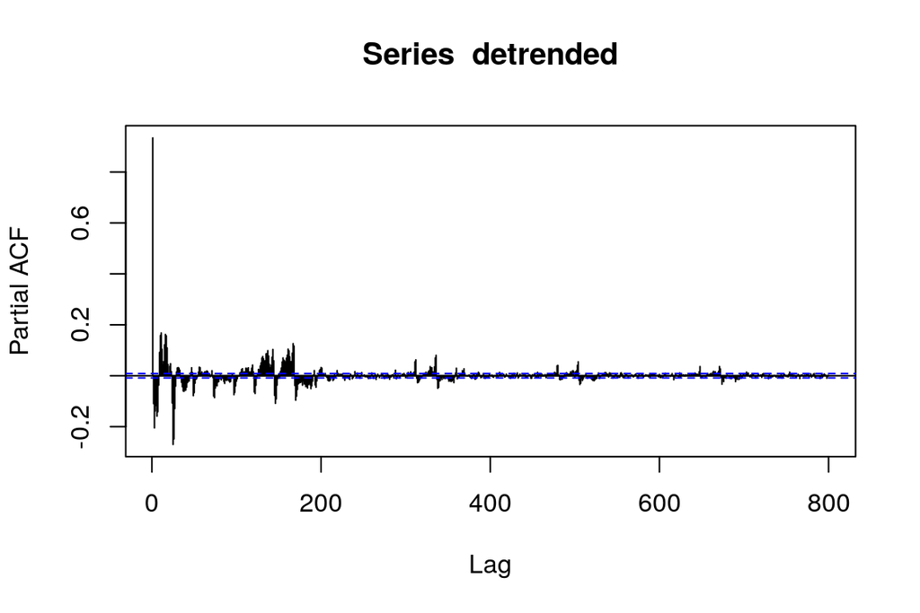

```r
# R
pacf(detrended, lag.max=800)
```

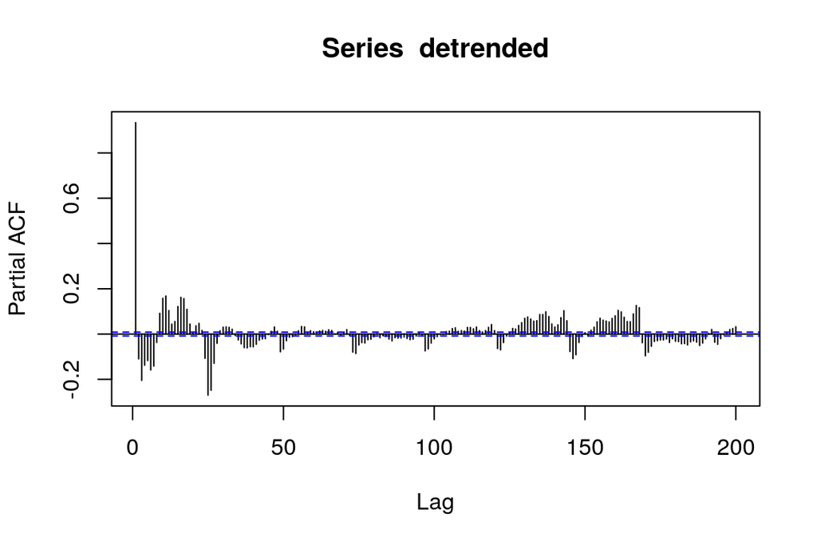

```r
# R
pacf(detrended, lag.max=200)
```

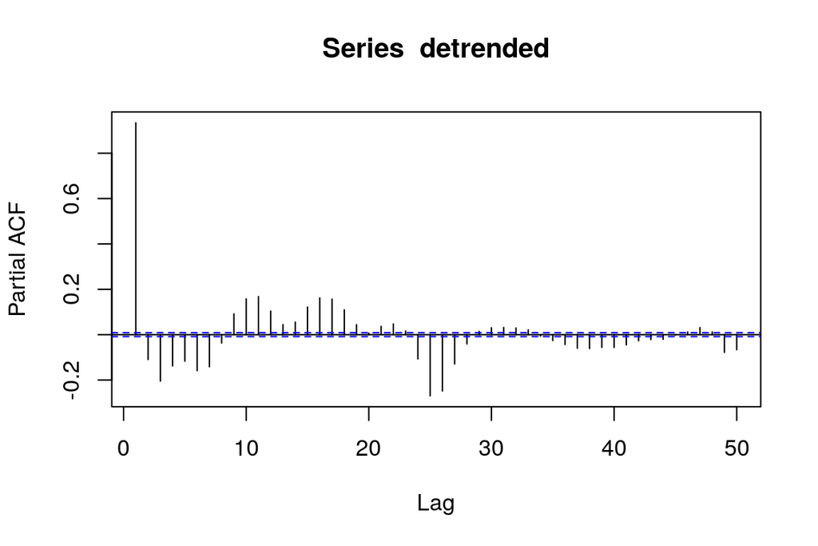

```r
# R
pacf(detrended, lag.max=50)
```

We see that there is very little partial autocorrelation when the data points are more than 200 hours apart. The largest spikes in partial autocorrelation reside within the 0 to 48 hours range. To reduce our computational burden, we determine the likely range of AR order to be between 0 and 48.

We then plot the Autocorrelation Function (ACF) in the following figures, using timespan of 9000 hours (about 1 year), 800 hours (about 1 month), 200 hours (about 1 week), and 50 hours (about 2 days).

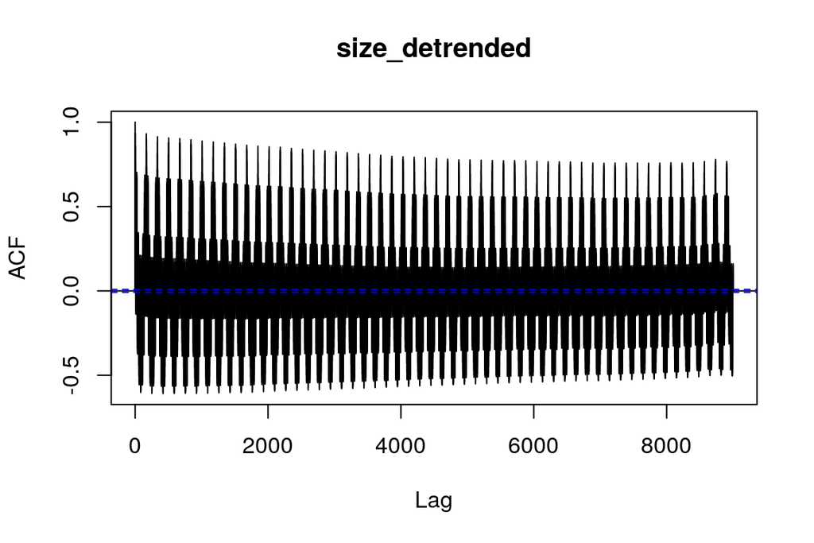

```r
# R
acf(detrended, lag.max=9000)
```

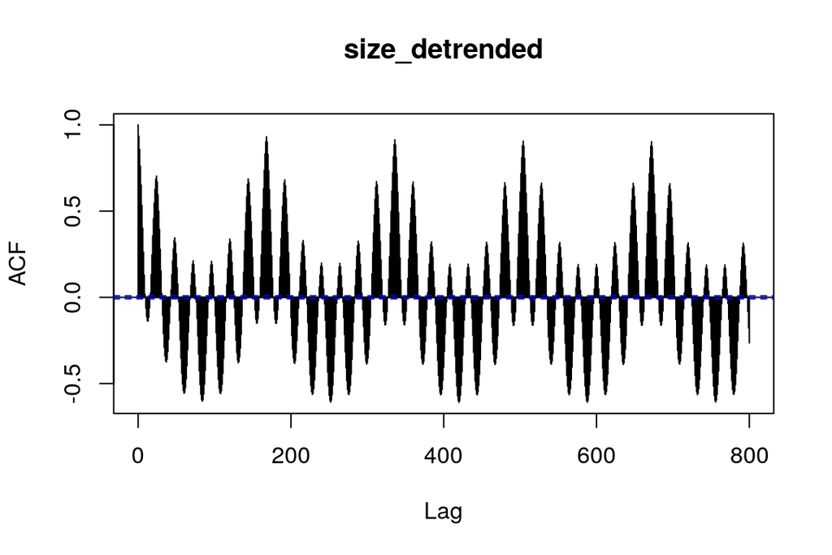

```r
# R
acf(detrended, lag.max=800)
```

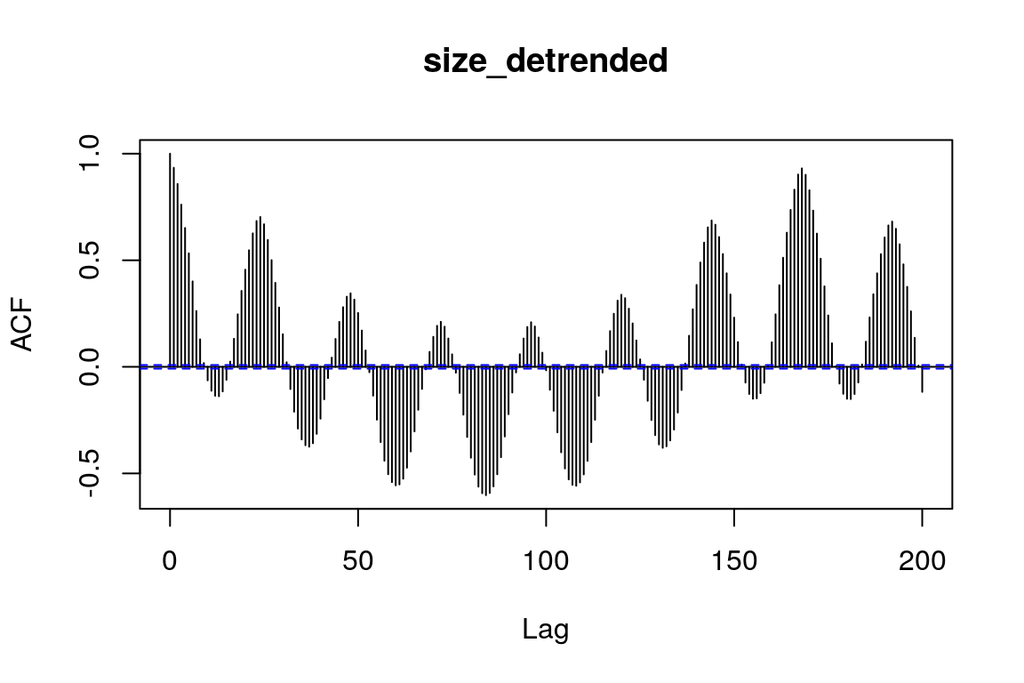

```r
# R
acf(detrended, lag.max=200)
```

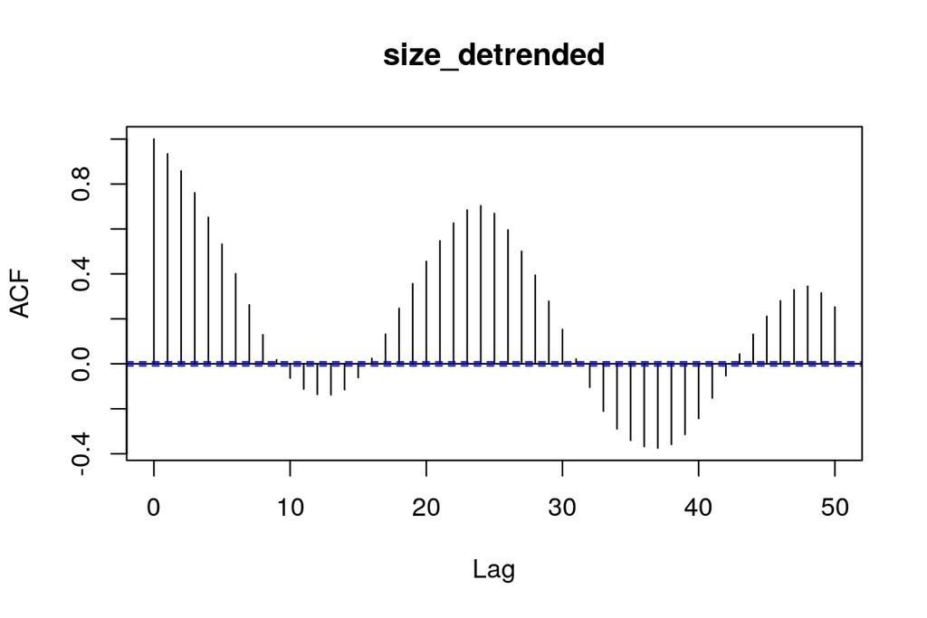

```r
# R
acf(detrended, lag.max=50)
```

Because of the multiple periodic patterns present in our series, it’s not easy to tell the likely Moving Average (MA) order using the ACF charts. The MA order determines how many errors terms in the immediate past is used for fitting the model. To keep things going, we arbitrary determine a likely MA order of 0 through 24. If the search algorithm prefers a large MA order within that range, then the search range will be expanded as needed.

First we search for the best model with a 24 hour daily lag. This takes about 30 minutes to compute. It seems like we might have overestimated our range of likely parameters earlier, as the algorithm settled with rather small autoregressive and moving average orders (p=1, q=0, P=3, Q=0).

```r
# R
library(forecast)
p_upper = 48
q_upper = 24
start_p = p_upper%/%2
start_q = q_upper%/%2
stepwise = TRUE
parallel = FALSE
ts_fit = ts(detrended, frequency=24)
autoarima = auto.arima(ts_fit, max.p=p_upper, max.q=q_upper, max.d=0, seasonal=TRUE, max.P=p_upper, max.Q=q_upper, max.D=0, ic="aic", nmodels=((p_upper+1)*(q_upper+1))^2, stepwise=stepwise, parallel=parallel, max.order=(p_upper+q_upper)*2, start.p = start_p, start.q = start_q, start.P = start_p, start.Q = start_q)
autoarima_forecasts = forecast(autoarima, h=py$num_forecasts, level=80)
#autoarima_forecasts = forecast(autoarima, h=5, level=80)
fits = autoarima$fitted
predictions = autoarima_forecasts$mean
lower_bounds = autoarima_forecasts$lower
upper_bounds = autoarima_forecasts$upper
params = autoarima$arma
```

```python
# Python
sarima_models = []

def plot_forecasts(dataframe, fit_start=fit_horizon_start, forecast_start=forecast_horizon_start):
    ax = dataframe[['size', 'cma_for_extrapolation', 'forecasts']].plot(alpha=.6)
    ax.axvspan(fit_start, forecast_start, facecolor='green', edgecolor='none', alpha=.4)
    ax.axvspan(forecast_start, dataframe.index[-1], facecolor='orange', edgecolor='none', alpha=.4)
    ax.set_title('Model fitting horizon is green; Forecast horizon is yellow.', loc='right', fontdict={'fontsize':6})
    return ax

def plot_forecasts_errors(dataframe, fit_start=fit_horizon_start, forecast_start=forecast_horizon_start):
    ax = dataframe[['errors']].plot(alpha=.6)
    ax.axvspan(fit_start, forecast_start, facecolor='green', edgecolor='none', alpha=.4)
    ax.axvspan(forecast_start, dataframe.index[-1], facecolor='orange', edgecolor='none', alpha=.4)
    ax.set_title('Model fitting horizon is green; Forecast horizon is yellow.', loc='right', fontdict={'fontsize':6})
    return ax

def sarima_string_def(params):
    return f'SARIMA(p={params[0]}, d=0, q={params[1]})(S={params[4]}, P={params[2]}, D=0, Q={params[3]})'

fits = np.array(r.fits, dtype=np.float).flatten()
predictions = np.array(r.predictions, dtype=np.float)
lower_bounds = np.array(r.lower_bounds, dtype=np.float).flatten()
upper_bounds = np.array(r.upper_bounds, dtype=np.float).flatten()

df['forecasts'] = np.nan
forecasts = df['forecasts'].values.copy()
num_extrapolations = len(df[fit_horizon_start:])
extrapolation_indices = df.index >= fit_horizon_start
forecasts[extrapolation_indices] = cmas[extrapolation_indices] *  (np.concatenate([fits, predictions]) + 1)
df['forecasts'] = forecasts

df['lower_bounds'] = np.nan
lower = df['lower_bounds'].values.copy()
df['upper_bounds'] = np.nan
upper = df['upper_bounds'].values.copy()
num_preds = len(df[forecast_horizon_start:])
pred_indices = df.index >= forecast_horizon_start
lower[pred_indices] = cmas[pred_indices] * (lower_bounds + 1)
upper[pred_indices] = cmas[pred_indices] * (upper_bounds + 1)
df['lower_bounds'] = lower
df['upper_bounds'] = upper

df['errors'] = (df['forecasts'] - df['size'])

forecast_horizon = df[forecast_horizon_start:]
nrmse = forecast_horizon['errors'].abs().mean()/forecast_horizon['size'].mean()
picr = np.count_nonzero(np.logical_and((forecast_horizon['size'].values > forecast_horizon['lower_bounds'].values), (forecast_horizon['size'].values < forecast_horizon['upper_bounds'].values)))/num_preds
params = r.params
string_def = sarima_string_def(params)
sarima_models.append({"model":string_def, "nrmse":nrmse, "picr":picr, "forecast_plot": plot_forecasts(df), "error_plot": plot_forecasts_errors(df)})
print(f"{string_def}, NRMSE: {nrmse}, PICR: {picr}")
```

Then we search for the best SARIMA model with a weekly seasonal order. However, for some reason this takes much longer to run does not terminate after an hour. We therefore decide to narrow down the range of likely AR and MA orders to be between 0 and 5, to reduce the computational burden. This is reasonable considering that the search heuristic settles on a low order model for the daily seasonal configuration.

```r
# R
library(forecast)
p_upper = 5
q_upper = 5
start_p = p_upper%/%2
start_q = q_upper%/%2
stepwise = TRUE
parallel = FALSE
ts_fit = ts(detrended, frequency=24*7)
autoarima = auto.arima(ts_fit, max.p=p_upper, max.q=q_upper, max.d=0, seasonal=TRUE, max.P=p_upper, max.Q=q_upper, max.D=0, ic="aic", nmodels=((p_upper+1)*(q_upper+1))^2, stepwise=stepwise, parallel=parallel, max.order=(p_upper+q_upper)*2, start.p = start_p, start.q = start_q, start.P = start_p, start.Q = start_q)
autoarima_forecasts = forecast(autoarima, h=py$num_forecasts, level=80)
#autoarima_forecasts = forecast(autoarima, h=5, level=80)
fits = autoarima$fitted
predictions = autoarima_forecasts$mean
lower_bounds = autoarima_forecasts$lower
upper_bounds = autoarima_forecasts$upper
params = autoarima$arma
```

```python
# Python
fits = np.array(r.fits, dtype=np.float).flatten()
predictions = np.array(r.predictions, dtype=np.float)
lower_bounds = np.array(r.lower_bounds, dtype=np.float).flatten()
upper_bounds = np.array(r.upper_bounds, dtype=np.float).flatten()

df['forecasts'] = np.nan
forecasts = df['forecasts'].values.copy()
num_extrapolations = len(df[fit_horizon_start:])
extrapolation_indices = df.index >= fit_horizon_start
forecasts[extrapolation_indices] = cmas[extrapolation_indices] *  (np.concatenate([fits, predictions]) + 1)
df['forecasts'] = forecasts

df['lower_bounds'] = np.nan
lower = df['lower_bounds'].values.copy()
df['upper_bounds'] = np.nan
upper = df['upper_bounds'].values.copy()
num_preds = len(df[forecast_horizon_start:])
pred_indices = df.index >= forecast_horizon_start
lower[pred_indices] = cmas[pred_indices] * (lower_bounds + 1)
upper[pred_indices] = cmas[pred_indices] * (upper_bounds + 1)
df['lower_bounds'] = lower
df['upper_bounds'] = upper

df['errors'] = (df['forecasts'] - df['size'])

forecast_horizon = df[forecast_horizon_start:]
nrmse = forecast_horizon['errors'].abs().mean()/forecast_horizon['size'].mean()
picr = np.count_nonzero(np.logical_and((forecast_horizon['size'].values > forecast_horizon['lower_bounds'].values), (forecast_horizon['size'].values < forecast_horizon['upper_bounds'].values)))/num_preds
params = r.params
string_def = sarima_string_def(params)
sarima_models.append({"model":string_def, "nrmse":nrmse, "picr":picr, "forecast_plot": plot_forecasts(df), "error_plot": plot_forecasts_errors(df)})
print(f"{string_def}, NRMSE: {nrmse}, PICR: {picr}")
```

Lastly we attempt to search for the best model with an annual seasonal order. It does not terminate after three hours despite using a narrowed down search space. This shows inconsistency in computing performance between SARIMA models of different seasonal lags. It might be caused by the rather slow performance of the R programming language, or other algorithmic complexity issues related to the seasonal order. Luckily we know from previous analysis that the fluctuations happening on an annual basis are not strong compared to those on a weekly or daily basis, so not much value is lost from not having this model.

```r
# R
ts_fit = ts(detrended, frequency=24*365)
autoarima = auto.arima(ts_fit, max.p=p_upper, max.q=q_upper, max.d=0, seasonal=TRUE, max.P=p_upper, max.Q=q_upper, max.D=0, ic="aic", stepwise=FALSE, parallel=parallel)
autoarima_forecasts = forecast(autoarima, h=py$num_forecasts, level=80)
#autoarima_forecasts = forecast(autoarima, h=5, level=80)
fits = autoarima$fitted
predictions = autoarima_forecasts$mean
lower_bounds = autoarima_forecasts$lower
upper_bounds = autoarima_forecasts$upper
params = autoarima$arma
```

```python
# Python
fits = np.array(r.fits, dtype=np.float).flatten()
predictions = np.array(r.predictions, dtype=np.float)
lower_bounds = np.array(r.lower_bounds, dtype=np.float).flatten()
upper_bounds = np.array(r.upper_bounds, dtype=np.float).flatten()

df['forecasts'] = np.nan
forecasts = df['forecasts'].values.copy()
num_extrapolations = len(df[fit_horizon_start:])
extrapolation_indices = df.index >= fit_horizon_start
forecasts[extrapolation_indices] = cmas[extrapolation_indices] *  (np.concatenate([fits, predictions]) + 1)
df['forecasts'] = forecasts

df['lower_bounds'] = np.nan
lower = df['lower_bounds'].values.copy()
df['upper_bounds'] = np.nan
upper = df['upper_bounds'].values.copy()
num_preds = len(df[forecast_horizon_start:])
pred_indices = df.index >= forecast_horizon_start
lower[pred_indices] = cmas[pred_indices] * (lower_bounds + 1)
upper[pred_indices] = cmas[pred_indices] * (upper_bounds + 1)
df['lower_bounds'] = lower
df['upper_bounds'] = upper

df['errors'] = (df['forecasts'] - df['size'])

forecast_horizon = df[forecast_horizon_start:]
nrmse = forecast_horizon['errors'].abs().mean()/forecast_horizon['size'].mean()
picr = np.count_nonzero(np.logical_and((forecast_horizon['size'].values > forecast_horizon['lower_bounds'].values), (forecast_horizon['size'].values < forecast_horizon['upper_bounds'].values)))/num_preds
params = r.params
string_def = sarima_string_def(params)
sarima_models.append({"model":string_def, "nrmse":nrmse, "picr":picr, "forecast_plot": plot_forecasts(df), "error_plot": plot_forecasts_errors(df)})
print(f"{string_def}, NRMSE: {nrmse}, PICR: {picr}")
```

We present the NRMSE and PI CR of the two successfully fitted SARIMA models in the following table.

```python
# Python
models = pd.DataFrame.from_dict(sarima_models)
results = models[['model', 'nrmse', 'picr']]
```

```r
# R
results = py$results
kable_styling(kable(results, format = "html", booktabs = T), position="center")
```

| model | nrmse | picr |
| --- | --- | --- |
| SARIMA(p=1, d=0, q=0)(S=24, P=3, D=0, Q=0) | 0.3808470 | 0.7806284 |
| SARIMA(p=5, d=0, q=2)(S=168, P=0, D=0, Q=0) | 0.3813759 | 0.7868179 |

Interestingly, the search algorithm chose to not include any seasonal terms when the order is set to a week apart rather than a day apart. Alarmingly, the relative errors (NMRSE) of both models are quite large. Recall from the spectral analysis earlier, our time series has multiple periodic/seasonal patterns, but any SARIMA model can only accomodate one single seasonal lag - could this be leading to the large forecast errors? In this next section we explore an alternative approach that takes into account multiple periodic patterns.

### Fourier Extrapolation

In the Spectral Analysis section, we utilized Fast Fourier Transform (FFT) to map the datapoints equally spaced in the time domain into waves in the frequency domain, the amplitudes of which we visualized in the periodogram. In this section we explore ways to extrapolate the waves beyond the datapoints $\{y_{transformed, t}|t\in fit\}$ to estimate $\{y_{periodic, t}|t\in forecast\}$ and $\{y_{t}|t\in forecast\}$. In line with our methodology, the objective of this section is to obtain a Fourier model with low forecasting errors and a robust statistical distribution of forecasting errors.

Recall from the Data Analysis section that $y_{transformed, t} = \hat{y}_{periodic, t} + \epsilon_{transformed, t}$, where $y_{periodic, t}$ are compositions of wave-like periodic patterns repeating themselves, and $\epsilon_{transformed, t}$ are small random disturbances in our series. Thus the trignometric waves approximated by FFT on $y_{transformed, t}$ are great at modeling $y_{periodic, t}$. We present a naive attempt at “extrapolation” below by simply feeding the forecast time values $\{t|t\in forecast\}$ into the trignometric functions. We implemented the parallel extrapolation with GPU to cut down the extrapolation time from half a minute to about a second. The CPU extrapolation time takes half a minute because using DFT on a large dataset results in a long Fourier series. Below we visualize the forecasts and calculate the errors of this naive approach.

```python
# Python
def generate_wave(ts, amplitude, frequency, phaseshift):
    return amplitude * np.cos(2 * np.pi * frequency * ts + phaseshift)

# gpu extrapolation
import cupy as cp
def dft_extrapolate_cuda(freqdom, num_datapoints):
    num_batches = 20
    n = freqdom.size
    gen_wave = lambda t, A, f, phi: A * cp.cos(2 * cp.pi * f * t + phi)
    freqdom = cp.array(freqdom)
    amplitudes = cp.absolute(freqdom)/n
    phaseshifts = cp.angle(freqdom)
    frequencies = cp.fft.fftfreq(n)
    batch_size = num_datapoints // num_batches
    results = cp.empty(num_datapoints)
    start = 0
    end = 0
    for i in range(num_batches):
        start = batch_size * i
        end = num_datapoints if end > num_datapoints else batch_size * (i + 1)
        t_slice = cp.arange(start, end)
        results[start:end] = cp.sum(gen_wave(cp.expand_dims(t_slice, axis=1), amplitudes, frequencies, phaseshifts), axis=1)
    return cp.asnumpy(results)

signal_fft = np.fft.fft(fitting_horizon['size_detrended'])

df['forecasts'] = np.nan
forecasts = df['forecasts'].values.copy()
num_extrapolations = len(df[fit_horizon_start:])
extrapolation_indices = df.index >= fit_horizon_start
forecasts[extrapolation_indices] = cmas[extrapolation_indices] *  (dft_extrapolate_cuda(signal_fft, num_extrapolations) + 1)
df['forecasts'] = forecasts
df['errors'] = (df['forecasts'] - df['size'])

forecast_horizon = df[forecast_horizon_start:]
nrmse = forecast_horizon['errors'].abs().mean()/forecast_horizon['size'].mean()
print(f"NRMSE: {nrmse}")
```

```
## NRMSE: 0.26504276383934694
```

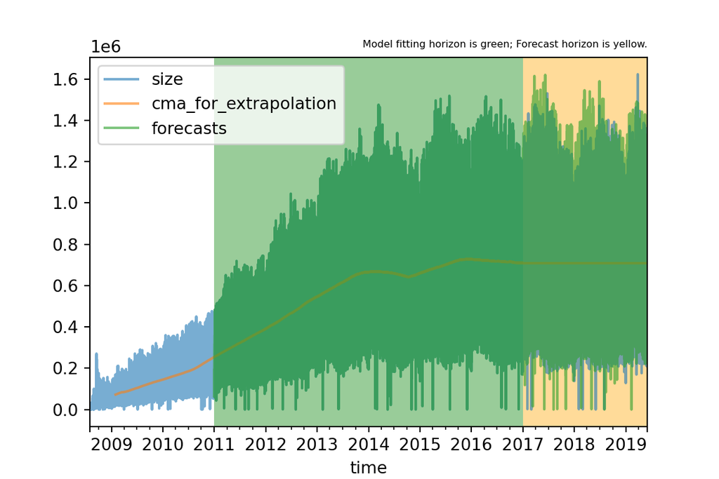

```python
# Python
plot_forecasts(df)
```

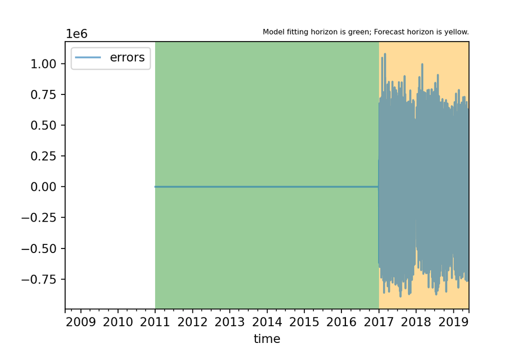

```python
# Python
plot_forecasts_errors(df)
```

We see that even with our naive approach, the NRMSE is much lower than the SARIMA models. This shows the deficiency of SARIMA models when dealing with multiple seasonal patterns. Notably, the “forecasts” of our naive approach can be mathematically proven to be identical to repeating $\{y_{transformed, t}|t\in fit\}$ as $\{\hat{y}_{periodic, t}|t\in forecast\}$. That is, we are simply multiplying the last available moving average in the fitting horizon by the detrended series in the fitting horizon to obtain our estimates for the forecasting horizon. Still, it outperforms the SARIMA models in terms of forecasting errors. However, we see from the above plot of forecast errors, the errors in the fitting horizon are precisely zero. This is because our extrapolation technique can be understood as an extended inverse Fourier transform. This means that if we do not modify the Fourier series, it always exactly reproduces the data it is fed in, which prevents us from estimating a distribution of forecast errors.

To predict the distribution of forecasting errors without measuring them directly, we need our Fourier series to represent $\{\hat{y}_{periodic, t}|t\in fit\}$ rather than $\{y_{transformed, t}|t\in fit\}$. In layman’s terms, our Fourier series needs to capture only the periodic patterns but not the noise. To do this, we apply a simple filtering approach by removing the waves with time periods of more than a year or less than 5 hours, as well as the ones with an amplitude smaller than 0.005. Intuitively, the relevant periodic patterns should not have very high or low frequencies, or very low amplitudes. A beneficial side effect of this filter is that our Fourier series is now small enough to be extrapolated by a CPU in less than a second. We calculates its errors and visualize its forecasts below.

```python
# Python
def dft_extrapolate_filtered_cpu(freqdom, num_datapoints, index_filter_conditions):
    n = freqdom.size
    amplitudes = np.absolute(freqdom)/n
    phaseshifts = np.angle(freqdom)
    frequencies = np.fft.fftfreq(n)
    ts = np.arange(0, num_datapoints)
    # wave = np.sum(generate_wave(np.expand_dims(ts, axis=1), amplitudes, frequencies, phaseshifts), axis=1)
    indices = np.arange(n)
    unfiltered_indices = indices[~index_filter_conditions]
    return np.sum(generate_wave(np.expand_dims(ts, axis=1), amplitudes[unfiltered_indices], frequencies[unfiltered_indices], phaseshifts[unfiltered_indices]), axis=1)

sample_rate = 60**-2 # once per hour in Hz
n = len(fitting_horizon)
non_constant_signal_fft = signal_fft[1:] # first term has frequency of zero which is just a constant term
amplitudes = np.absolute(non_constant_signal_fft)/n
frequencies_hz = (np.arange(0, n, 1) * sample_rate / n)[1:]
periods_hours = (1/frequencies_hz)/((60**2))
periods_days = (1/frequencies_hz)/((60**2)*24)
filtered_indices = np.insert((periods_hours < 5) + (periods_days > 365.25) + (amplitudes < 0.005),0,[True])

df['forecasts'] = np.nan
forecasts = df['forecasts'].values.copy()
num_extrapolations = len(df[fit_horizon_start:])
extrapolation_indices = df.index >= fit_horizon_start
forecasts[extrapolation_indices] = cmas[extrapolation_indices] *  (dft_extrapolate_filtered_cpu(signal_fft, num_extrapolations, filtered_indices) + 1)
df['forecasts'] = forecasts
df['errors'] = (df['forecasts'] - df['size'])

forecast_horizon = df[forecast_horizon_start:]
nrmse = forecast_horizon['errors'].abs().mean()/forecast_horizon['size'].mean()
print(f"NRMSE: {nrmse}")
```

```
## NRMSE: 0.2762466596127651
```

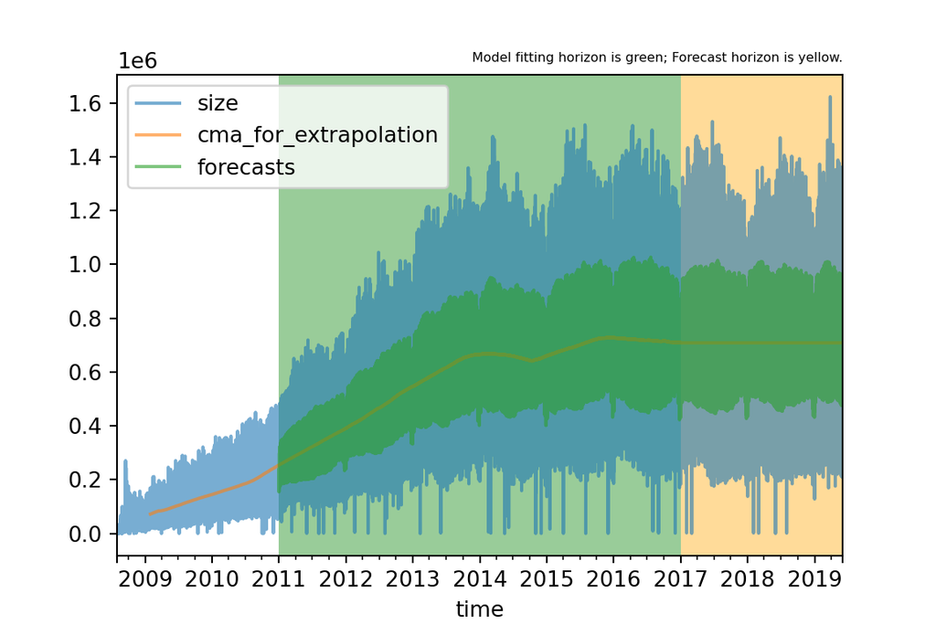

```python
# Python
plot_forecasts(df)
```

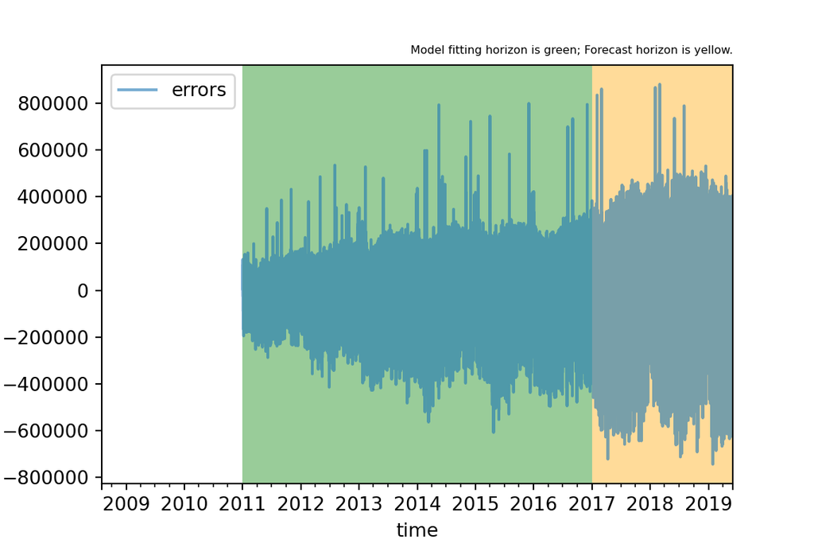

```python
# Python
plot_forecasts_errors(df)
```

After applying the filter, we have a fitting error distribution that might be somewhat informative for estimating forecast error distribution. However our forecast accuracy is now worse off (higher NRMSE)! We observe that this is because the high frequency waves are responsible for “propping up” the magnitudue of the fluctuations. The fix this, we apply a simple amplifier through multiplying our periodic waves by two. We visualize the amplified forecasts and calculates their errors below.

```python
# Python
sample_rate = 60**-2 # once per hour in Hz
n = len(fitting_horizon)
non_constant_signal_fft = signal_fft[1:] # first term has frequency of zero which is just a constant term
amplitudes = np.absolute(non_constant_signal_fft)/n
frequencies_hz = (np.arange(0, n, 1) * sample_rate / n)[1:]
periods_hours = (1/frequencies_hz)/((60**2))
periods_days = (1/frequencies_hz)/((60**2)*24)
filtered_indices = np.insert((periods_hours < 5) + (periods_days > 365.25) + (amplitudes < 0.005),0,[True])
amp = 2

df['forecasts'] = np.nan
forecasts = df['forecasts'].values.copy()
num_extrapolations = len(df[fit_horizon_start:])
extrapolation_indices = df.index >= fit_horizon_start
forecasts[extrapolation_indices] = cmas[extrapolation_indices] *  (amp * dft_extrapolate_filtered_cpu(signal_fft, num_extrapolations, filtered_indices) + 1)
df['forecasts'] = forecasts
df['errors'] = (df['forecasts'] - df['size'])

forecast_horizon = df[forecast_horizon_start:]
nrmse = forecast_horizon['errors'].abs().mean()/forecast_horizon['size'].mean()
print(f"NRMSE: {nrmse}")
```

```
## NRMSE: 0.25009608433824704
```

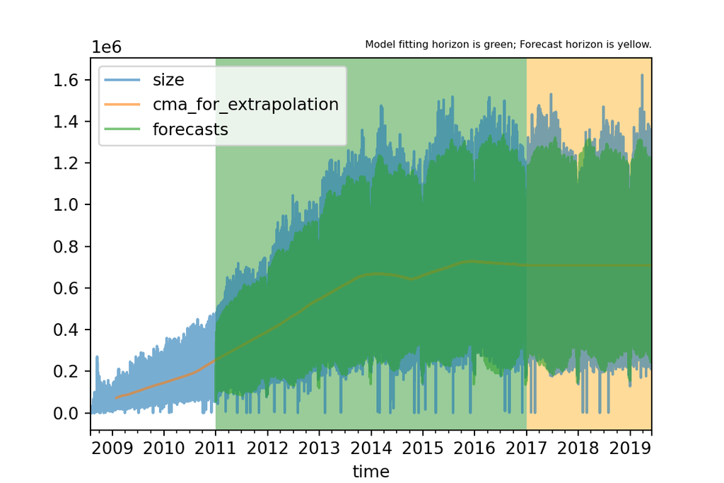

```python
# Python
plot_forecasts(df)
```

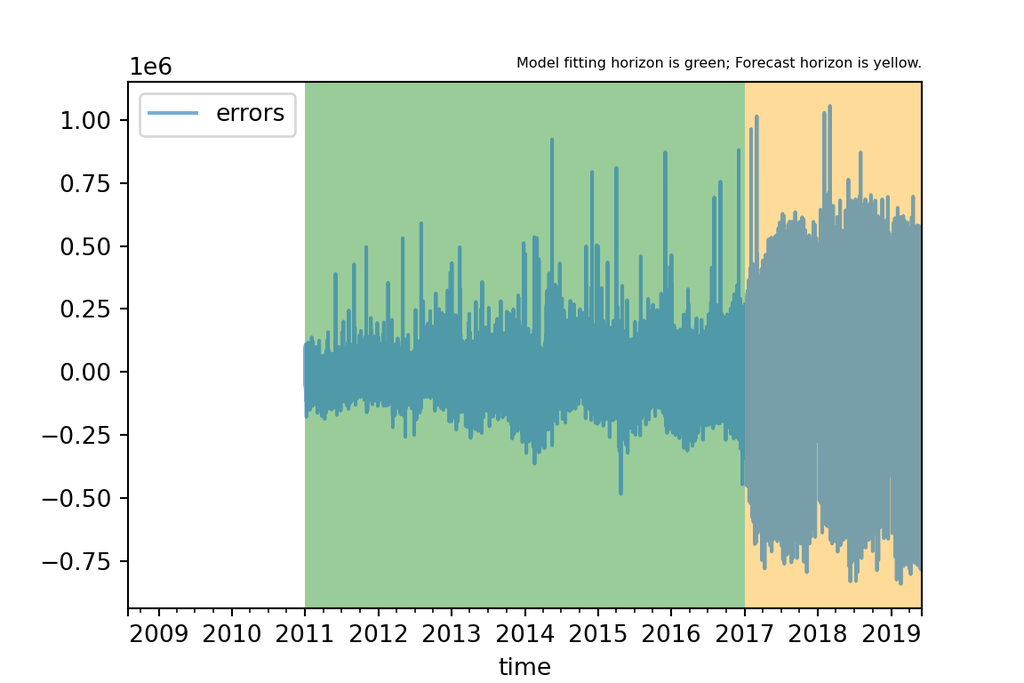

```python
# Python
plot_forecasts_errors(df)
```

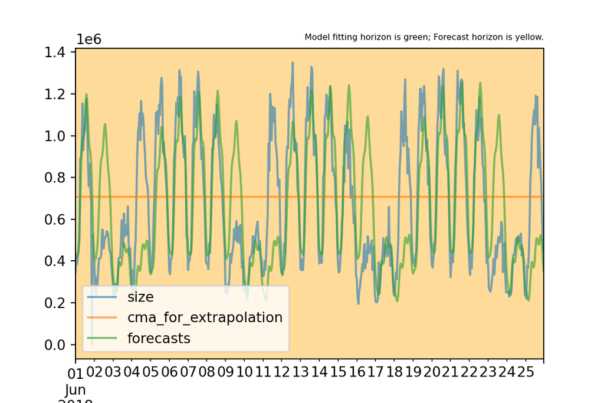

```python
# Python
plot_forecasts(df['2018-06-01':'2018-06-25'])
```

The predicted weekly traffic patterns above are incorrectly “shifted right” by a day, which leads to large errors on Mondays and Saturdays. Recall that the Fast Fourier Transform models the patterns in the fitting horizon exactly - since the fitting horizon (2011 - 2016) starts on a Saturday and the forecast horizon (2017 - 2019) starts on a Sunday, the weeks in our wave forecasts are misaligned. While it is possible to change the phaseshifts of our waves with a weekly frequency, we apply a simple fix to this problem by beginning our fitting horizon on 2012, which starts on a Sunday. We visualize the forecasts and calculates their errors below.

```python
# Python
sunday_fit_horizon_start = np.datetime64("2012-01-01T00:00:00")
sunday_fitting_horizon = filtered_df[sunday_fit_horizon_start:forecast_horizon_start - np.timedelta64(1,"h")].copy()
sunday_signal_fft = np.fft.fft(sunday_fitting_horizon['size_detrended'])

n = len(sunday_fitting_horizon)
non_constant_signal_fft = sunday_signal_fft[1:] # first term has frequency of zero which is just a constant term
amplitudes = np.absolute(non_constant_signal_fft)/n
frequencies_hz = (np.arange(0, n, 1) * sample_rate / n)[1:]
periods_hours = (1/frequencies_hz)/((60**2))
periods_days = (1/frequencies_hz)/((60**2)*24)
filtered_indices = np.insert((periods_hours < 5) + (periods_days > 365.25) + (amplitudes < 0.005),0,[True])
amp = 2

df['forecasts'] = np.nan
forecasts = df['forecasts'].values.copy()
num_extrapolations = len(df[sunday_fit_horizon_start:])
num_forecasts = len(df[forecast_horizon_start:])
extrapolation_indices = df.index >= sunday_fit_horizon_start
fits = cmas[extrapolation_indices] *  (amp * dft_extrapolate_filtered_cpu(sunday_signal_fft, num_extrapolations, filtered_indices) + 1)
forecasts[extrapolation_indices] = fits
df['forecasts'] = forecasts
df['errors'] = (df['forecasts'] - df['size'])

forecast_horizon = df[forecast_horizon_start:]
nrmse = forecast_horizon['errors'].abs().mean()/forecast_horizon['size'].mean()
print(f"NRMSE: {nrmse}")
```

```
## NRMSE: 0.11429576329114456
```

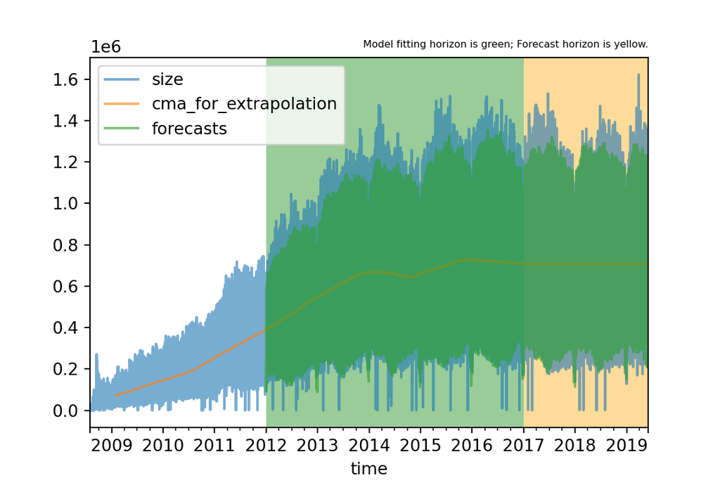

```python
# Python
plot_forecasts(df, sunday_fit_horizon_start, forecast_horizon_start)
```

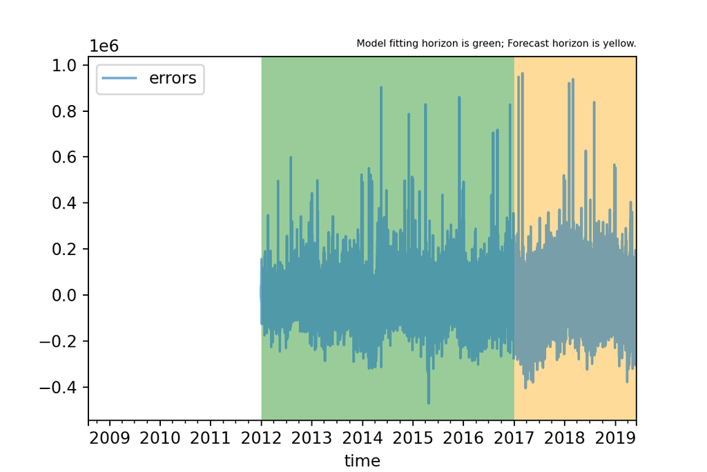

```python
# Python
plot_forecasts_errors(df, sunday_fit_horizon_start, forecast_horizon_start)
```

With NMRSE around 0.11, this model drastically outperforms the other ones in terms of forecasting accuracy. In addition, the errors of this model appears to be quite stationary across the fitting and forecasting horizons. To build a 80% confidence level prediction interval for this model, we simply assume that the errors are normally distributed with the same mean and variance in the forecast horizon as in the fitting horizon. We implement this approach and calculate the PICR below.

```python
sample_std = (np.var(df[sunday_fit_horizon_start:forecast_horizon_start]['errors'].values, ddof=1))**0.5
sample_mean = np.mean(df[sunday_fit_horizon_start:forecast_horizon_start]['errors'].values)
df['lower_bounds'] = df['forecasts'] - 1.282 * sample_std + sample_mean
df['upper_bounds'] = df['forecasts'] + 1.282 * sample_std + sample_mean
picr = np.count_nonzero(np.logical_and((forecast_horizon['size'].values > forecast_horizon['lower_bounds'].values), (forecast_horizon['size'].values < forecast_horizon['upper_bounds'].values)))/num_preds
models = models.append({"model":"Fourier (Filtered, Amplified, Phase-Realigned)", "nrmse":nrmse, "picr":picr, "forecast_plot": plot_forecasts(df), "error_plot": plot_forecasts_errors(df)}, ignore_index=True)
print(f'PICR: {picr}')
```

[output not shown]

While not ideal, this is a good starting point for building better error distributions. We leave this for future work.

# Conclusions

```python
# Python
results = models[['model', 'nrmse', 'picr']]
```

```r
# R
results = py$results
kable_styling(kable(results, format = "html", booktabs = T), position="center")
```

| model | nrmse | picr |
| --- | --- | --- |
| SARIMA(p=1, d=0, q=0)(S=24, P=3, D=0, Q=0) | 0.3808470 | 0.7806284 |
| SARIMA(p=5, d=0, q=2)(S=168, P=0, D=0, Q=0) | 0.3813759 | 0.7868179 |
| Fourier (Filtered, Amplified, Phase-Realigned) | 0.1142958 | 0.6747933 |

As we can see from the table above, the SARIMA models underperform in terms of predictive power, with much higher NRMSE. However their statistical properties are more robust, and the PICR is close to the ideal rate of 0.8. On the other hand, our ad-hoc Fourier forecasting model has strong predictive power, but the statistical properties are less well understood. Thus its prediction intervals are further from the ideal distribution. For a website interested in forecasting site traffic, SARIMA models are not sufficient and lack ability to make accurate forecasts. Fourier series are able to capture more of the periodic fluctuations in hourly traffic, and a simple Fourier approach can serve as a good starting point for making strong forecasts. On the other hand, the statistical properties of Fourier extrapolations are less clear, which can hamstring some applications such as anomaly detection.

To summarize, in the context of forecasting web traffic, the pros of SARIMA models are:

1. they are widely used for time series with well understood statistical properties

The cons of SARIMA models are:

1. they are slow to compute (at least in R) when the seasonal order is large
2. they have bad forecasting power in the presence of multiple periodic patterns

The pros of the Fourier extrapolation models are:

1. their core algorithm, Fast Fourier Transform, is used by more than just statisticans and data scientists, and has existing implementations in many programming languages
2. they are very fast to compute compared to SARIMA, and does not require searching through potential parameters
3. they have surprisingly strong predictive power for periodic fluctuations

The cons of the Fourier extrapolation models are:

1. they have less understood statistical properties
2. they may require realignment of periodic phases, which can be very complicated

# Further Discussion

While SARIMA models underperformed in our report, for future work it is possible to combine the strength of SARIMA models and Fourier analysis by including trignometric regressor terms in SARIMAX. It is also possible to further improve the performance of our Fourier extrapolations through more advanced filtering techniques. Exponential smoothing models might be of interest as well, and they do not require the stationarity assumption. Deep learning models are another class of methods which have become overwhelmingly popular in recent years. Comparing these models may offer considerable insight for practitioners and researchers.

# References

[1] Perry Deng. 2019. PerryXDeng/proj_stack_exchange. *GitHub*. Retrieved from https://github.com/PerryXDeng/stack_exchange_text_mining

[2] Stack Exchange. 2019. Stack exchange data dump. *Internet Archive*. Retrieved from https://archive.org/details/stackexchange

[3] Stack Exchange. 2020. Stack exchange sites. Retrieved from https://stackexchange.com/sites?view=list

[4] Stack Exchange. 2020. Stack exchange performance. Retrieved from https://stackexchange.com/performance

[5] Kristy Hawkins. 2019. How netflix over-deployed 10,000 instances in amazon aws. Retrieved from https://www.itassetmanagement.net/2019/04/23/how-netflix-over-deployed-10000-instances-in-amazon-aws/

[6] Rob J. Hyndman and Yeasmin Khandakar. 2008. Automatic time series forecasting: The forecast package for r. *Journal of Statistical Software, Articles* 27, 3 (2008), 1–22. DOI:https://doi.org/10.18637/jss.v027.i03